# Sex Prediction from RNASeq Results

Bill Amadio

2019

### **Overview and Conclusion**

The 01-clean_split_data.R, 02-train_elasticnet.R, 03-evaluate_model.R pipeline trains and evaluates an elasticnet logistic regression model to predict sex from RNASeq data.  
The training features are gene expression transcripts, and the training labels are reported_gender values for each sample.

The pipeline is a response to issue [#84](https://github.com/AlexsLemonade/OpenPBTA-analysis/issues/84) which was raised to check whether, in some histologies, silencing might be breaking down, potentially resulting in changes in X inactivation. Based on the accuracy achieved here, this is probably not happening, and this classifier can be helpful to predict values for datasets without annotated sex information.

### **Strength of Calls**

The model generates a probability that a given sample is Female. Female/Male calls are made using a 50% threshold. Predictive accuracy varies by the number of training transcripts used.  
The plot below shows model probability values, generated by the most accurate set of training transcripts, for all 258 samples in the test set.  
The test set points are split on the x-axis by train_target_column (ground truth) values. Erroneous calls are displayed in red.

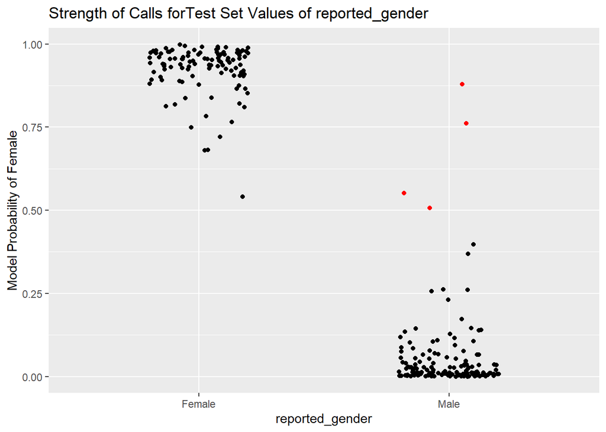

### **Predictive Accuracy**

Model accuracy was tested against germline_sex_estimate values in addition to reported_gender values.  
Confusion matrices for models using the most accurate set of training transcripts appear below.

```
##
## ####### Confusion Matrix for reported_gender Calls at Maximum Accuracy #######
## $positive
## [1] "Female"
##
## $table
##           Reference
## Prediction Female Male
##     Female    112    4
##     Male        0  142
##
## $overall
##       Accuracy          Kappa  AccuracyLower  AccuracyUpper   AccuracyNull
##   9.844961e-01   9.685749e-01   9.607819e-01   9.957600e-01   5.658915e-01
## AccuracyPValue  McnemarPValue
##   1.022493e-56   1.336144e-01
##
## $byClass
##          Sensitivity          Specificity       Pos Pred Value
##            1.0000000            0.9726027            0.9655172
##       Neg Pred Value            Precision               Recall
##            1.0000000            0.9655172            1.0000000
##                   F1           Prevalence       Detection Rate
##            0.9824561            0.4341085            0.4341085
## Detection Prevalence    Balanced Accuracy
##            0.4496124            0.9863014
##
## $mode
## [1] "sens_spec"
##
## $dots
## list()
##
## attr(,"class")
## [1] "confusionMatrix"
##
##
## ####### Two Class Summary for reported_gender Calls at Maximum Accuracy #######
##       ROC      Sens      Spec
## 0.9985323 1.0000000 0.9726027
```

[output cut: 27 more lines]

```
##
## $mode
## [1] "sens_spec"
##
## $dots
## list()
##
## attr(,"class")
## [1] "confusionMatrix"
##
##
## ####### Two Class Summary for germline_sex_estimate Calls at Maximum Accuracy #######
##       ROC      Sens      Spec
## 0.9985323 1.0000000 0.9726027
##
```

### **Training Guidance**

Training transcripts are filtered by median absolute deviation across all samples.  
The pipeline accepts an array of user-supplied training set sizes, and a model, using each training set size, is built, evaluated and saved. The plots below show predictive accuracies by number of training transcripts using reported_gender and germline_sex_estimate as ground truths.

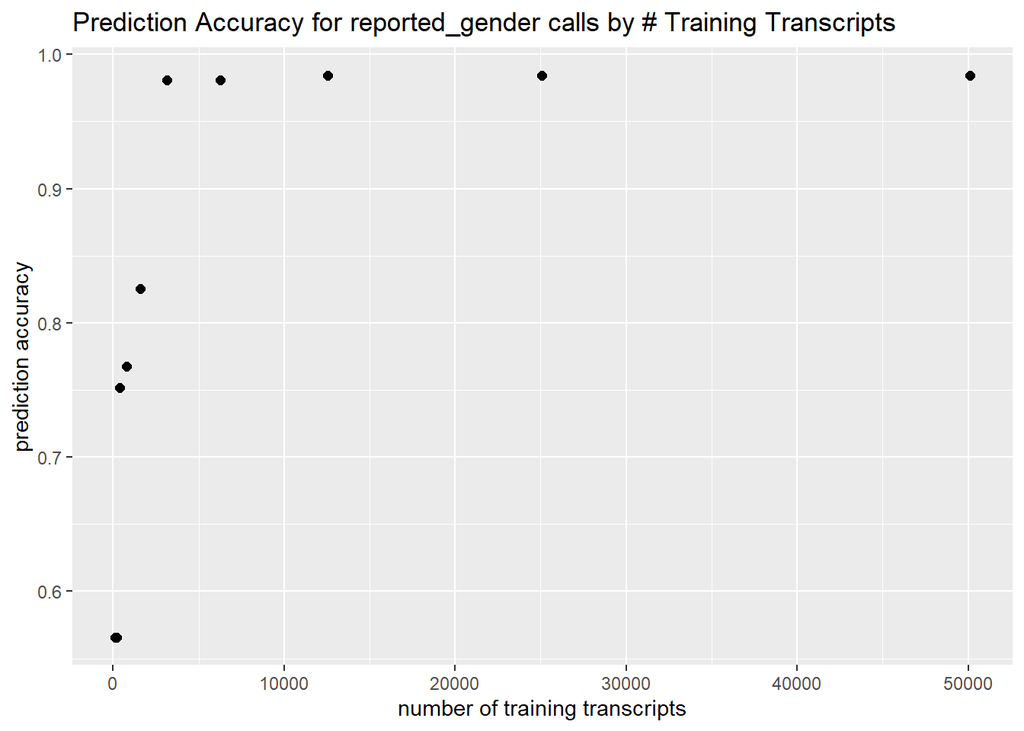

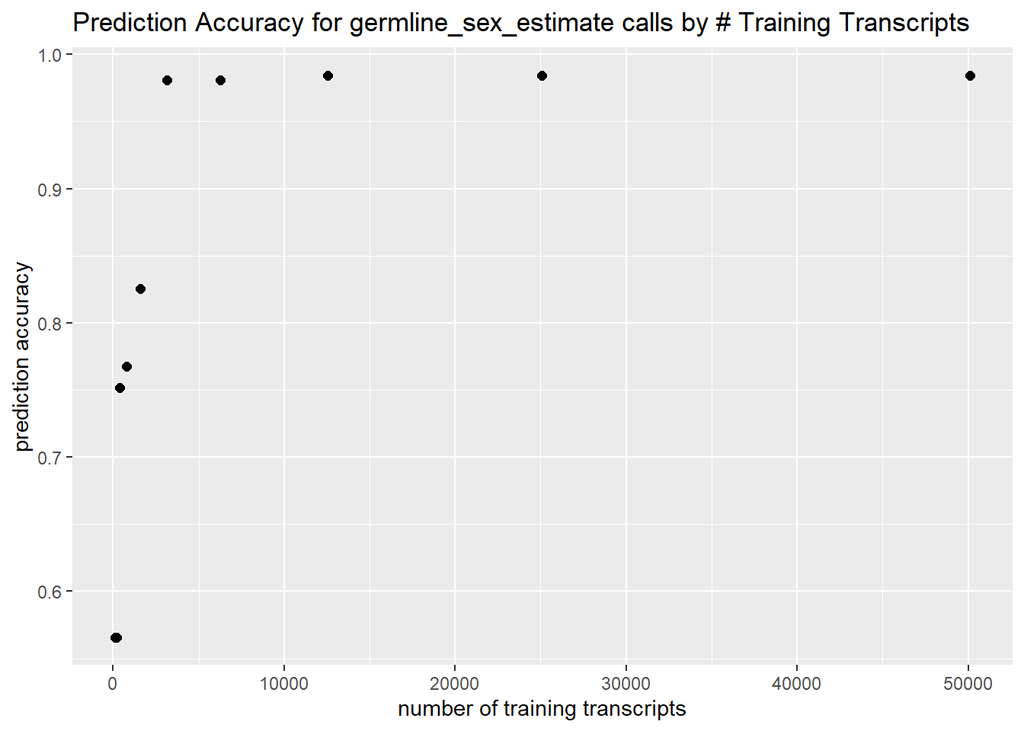

The number of non-zero features in each model varied considerably.  
The elastic net alpha parameter was optimized using the default sequence of 11 values more closely spaced around alpha = 0.

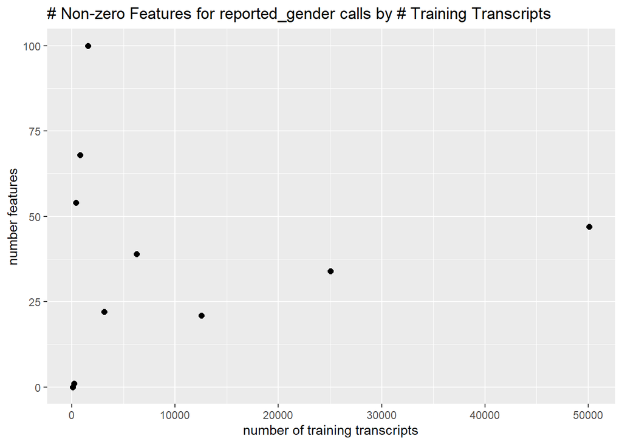

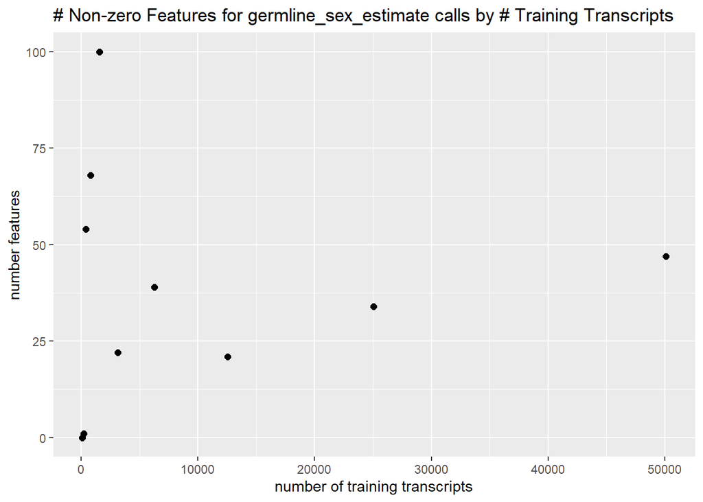